## Importing Necessary Packages

```python
#Libraries reated to dataframe management
import pandas as pd
import numpy as np

#Libraries related to neural network architecture
import tensorflow as tf
import keras as keras
from keras.models import Sequential
from keras.layers import Dense, Dropout
from keras.optimizers import Adam

#Libraries related to model performance
from sklearn.metrics import confusion_matrix
from sklearn.metrics import roc_curve, auc
from sklearn.metrics import classification_report
import matplotlib.pyplot as plt
import seaborn as sns

#Using random library for hyperparameter tuning
import random

from feature_engine.encoding import CountFrequencyEncoder
```

# Data Preprocessing

### Data Selection: Description of the Dataset and Selecting the Dataset

The dataset for this project is called "Cervical Cancer (Risk Factors)" which focuses on the prediction of indicators/diagnosis of cervical cancer. There are 36 features within the dataset which covers over demographic information, patients' habits, and historic medical records of 858 patients. It was collected at the 'Hospital Universitario de Caracas' in Caracas, Venezuela. Due to privacy concerns, some information is missing as patients were not obligated to share everything about their health.

The dataset was found on UCI Machine Learning Repository and was published by authors Kelwin Fernandes, Jaime Cardoso, and Jessica Fernandes. Link to dataset: https://archive.ics.uci.edu/dataset/383/cervical+cancer+risk+factors

Cervical cancer is a type of cancer that starts in the cervix and usually spreads to other body parts in its later critical stages. It is the fourth most common cancer found amongst women. The occurence of this disease illustrates the importance of understanding the different indicators that may lead to increased chances of cervical cancer in patients. Using a feedforward neural network (FNN) and having cervical cancer as the target (`Dx: Cancer`), FNN can be used for cancer classification due to its nature of learning complex patterns through hidden layer architecture.

```python
cervical_can_df = pd.read_csv('C:/Users/techa/OneDrive/Desktop/risk_factors_cervical_cancer.csv')
```

```python
cervical_can_df.info()
```

```
<class 'pandas.core.frame.DataFrame'>
RangeIndex: 858 entries, 0 to 857
Data columns (total 36 columns):
 #   Column                              Non-Null Count  Dtype
---  ------                              --------------  -----
 0   Age                                 858 non-null    int64
 1   Number of sexual partners           858 non-null    object
 2   First sexual intercourse            858 non-null    object
 3   Num of pregnancies                  858 non-null    object
 4   Smokes                              858 non-null    object
 5   Smokes (years)                      858 non-null    object
 6   Smokes (packs/year)                 858 non-null    object
 7   Hormonal Contraceptives             858 non-null    object
 8   Hormonal Contraceptives (years)     858 non-null    object
 9   IUD                                 858 non-null    object
```

[output cut: 28 more lines]

### Data Selection: Explanation of the variables of the dataset

#### Cervical Cancer Risk Factors Dataset Variables Description

| **Variable Name** | **Description** |
| --- | --- |
| `Age` | The age of the patient. |
| `Number of sexual partners` | Number of sexual partners the patient has had. |
| `First sexual intercourse` | Age at which the patient had their first sexual intercourse. |
| `Num of pregnancies` | The number of pregnancies the patient has had. |
| `Smokes` | Whether the patient is a smoker (`1` = smoker, `0` = non-smoker). |
| `Smokes (years)` | The number of years the patient has been smoking. |
| `Smokes (packs/year)` | The number of packs of cigarettes the patient smokes per year. |
| `Hormonal Contraceptives` | Whether the patient has used hormonal contraceptives (`1` = yes, `0` = no). |
| `Hormonal Contraceptives (years)` | The number of years the patient has used hormonal contraceptives. |
| `IUD` | Whether the patient has used an intrauterine device (IUD) (`1` = yes, `0` = no). |
| `IUD (years)` | The number of years the patient has used an intrauterine device (IUD). |
| `STDs` | Whether the patient has had any sexually transmitted diseases (`1` = yes, `0` = no). |
| `STDs (number)` | The number of sexually transmitted diseases the patient has had. |
| `STDs:condylomatosis` | Whether the patient has had condylomatosis, a type of genital wart (`1` = yes, `0` = no). |
| `STDs:cervical condylomatosis` | Whether the patient has had cervical condylomatosis, a type of genital wart (`1` = yes, `0` = no). |
| `STDs:vaginal condylomatosis` | Whether the patient has had vaginal condylomatosis, a type of genital wart (`1` = yes, `0` = no). |
| `STDs:vulvo-perineal condylomatosis` | Whether the patient has had vulvo-perineal condylomatosis, a type of genital wart (`1` = yes, `0` = no). |
| `STDs:syphilis` | Whether the patient has had syphilis (`1` = yes, `0` = no). |
| `STDs:pelvic inflammatory disease` | Whether the patient has had pelvic inflammatory disease (`1` = yes, `0` = no). |
| `STDs:genital herpes` | Whether the patient has had genital herpes (`1` = yes, `0` = no). |
| `STDs:molluscum contagiosum` | Whether the patient has had molluscum contagiosum (`1` = yes, `0` = no). |
| `STDs:HPV` | Whether the patient has had human papillomavirus (HPV) (`1` = yes, `0` = no). |
| `STDs:HIV` | Whether the patient has had HIV (`1` = yes, `0` = no). |
| `STDs:hepatitis B` | Whether the patient has had hepatitis B (`1` = yes, `0` = no). |
| `STDs: Number of Diagnosis` | The number of times the patient has had some form of STD (continuous) |
| `STDs:Time since first diagnosis` | The time that has passed since they first got some form of STD |
| `STDs:Time since last diagnosis` | The time that has passed since they last got some form of STD |
| `Dx: Cancer` | Whether the patient has had cervical cancer (`1` = yes, `0` = no). |
| `Dx: CIN` | Whether patient has had cervical intraepithelial neoplasia which is a precancerous condition that describes abnormal cells in the cervix (`1` = yes, `0` = no) |
| `Dx:HPV` | Whether that patient has had human papillomavirus (HPV) (`1` = yes, `0` = no). |
| `Dx:` | Whether that patient has had some general diagnosis, could be diagnosis of cervical issue (`1` = positive diagnosis, `0` = no diagnosis). |
| `Hinselmann:` | Results from the Hinselmann test, which is a dignostic test used to detect abnormal cells in the cervix. Used to identify precancerous leisons. (`1` = abnormal result, `0` = normal results). |
| `Schiller:` | Results from the Schiller test, a diagnostic test where iodine is applied to the cervix to detect abnormal cells that might indicate precancerous changes (`1` = abnormal result, `0` = normal results). |
| `Cytology:` | Results from the pap smear test which examines cervical cells for abnormalities. (`1` = abnormal result, `0` = normal results). |
| `Biopsy`: | Whether a biopsy was performed and if it was positive for precancerous leisons. (`1` = positive result, `0` = negative result). |

```python
cervical_can_df.head()
```

|  | Age | Number of sexual partners | First sexual intercourse | Num of pregnancies | Smokes | Smokes (years) | Smokes (packs/year) | Hormonal Contraceptives | Hormonal Contraceptives (years) | IUD | ... | STDs: Time since first diagnosis | STDs: Time since last diagnosis | Dx:Cancer | Dx:CIN | Dx:HPV | Dx | Hinselmann | Schiller | Citology | Biopsy |
| --- | --- | --- | --- | --- | --- | --- | --- | --- | --- | --- | --- | --- | --- | --- | --- | --- | --- | --- | --- | --- | --- |
| 0 | 18 | 4.0 | 15.0 | 1.0 | 0.0 | 0.0 | 0.0 | 0.0 | 0.0 | 0.0 | ... | ? | ? | 0 | 0 | 0 | 0 | 0 | 0 | 0 | 0 |
| 1 | 15 | 1.0 | 14.0 | 1.0 | 0.0 | 0.0 | 0.0 | 0.0 | 0.0 | 0.0 | ... | ? | ? | 0 | 0 | 0 | 0 | 0 | 0 | 0 | 0 |
| 2 | 34 | 1.0 | ? | 1.0 | 0.0 | 0.0 | 0.0 | 0.0 | 0.0 | 0.0 | ... | ? | ? | 0 | 0 | 0 | 0 | 0 | 0 | 0 | 0 |
| 3 | 52 | 5.0 | 16.0 | 4.0 | 1.0 | 37.0 | 37.0 | 1.0 | 3.0 | 0.0 | ... | ? | ? | 1 | 0 | 1 | 0 | 0 | 0 | 0 | 0 |
| 4 | 46 | 3.0 | 21.0 | 4.0 | 0.0 | 0.0 | 0.0 | 1.0 | 15.0 | 0.0 | ... | ? | ? | 0 | 0 | 0 | 0 | 0 | 0 | 0 | 0 |

5 rows × 36 columns

```python
cervical_can_df.shape
```

```
(858, 36)
```

### Data Selection: Sample Proportion of Target Variable

```
[Text(0, 0, '840'), Text(0, 0, '18')]
```

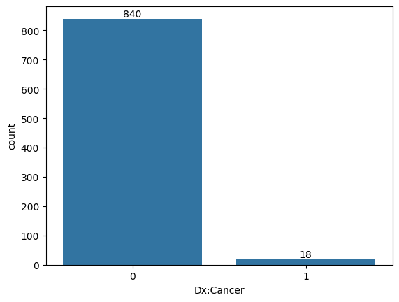

```python
ax = sns.countplot(x=cervical_can_df['Dx:Cancer'],
                   order=cervical_can_df['Dx:Cancer'].value_counts(ascending=False).index);

abs_values = cervical_can_df['Dx:Cancer'].value_counts(ascending=False).values

ax.bar_label(container=ax.containers[0], labels=abs_values)
```

The target response variable **`Dx:Cancer`** has a very imbalanced distribution of occurences.

1. `0`: means that there is no cancer
2. `1`: means that there is cancer

The imbalanced nature of the dataset suggests that SMOTE can be used to balance out the dataset after the dataset has been split into training, testing, and validation sets.

### Data Cleaning

#### Handling Missing Values

Missing values in this dataset appears in the form of question marks. Therefore, using **`.isnull()`** which is an attribute of the pandas dataframe is not possible. Therefore, there is a need to turn all the question marks values into null values and then count the number of missing values from each column. If the percentage of missing is greater than 30%, that data type will be dropped entirely as it suggests that a large proportion of that dataset is unavailable. However, if the percentage of missing is under 30%, I will need to impute missing values.

1. **Case 1:** If the variable is categorical, then the variable is imputed using mode imputation
2. **Case 2:** If the variable is numerical, then the variable is imputed using median imputation

```python
#calculating the percentage of missing for each column
missing_per_column = cervical_can_df.apply(lambda x: (x == '?').sum()).sort_values()

num_rows = cervical_can_df.shape[0]
null_cols = (missing_per_column / num_rows) * 100

print('Percentage of missing for each column:')
print(null_cols)
```

```
Percentage of missing for each column:
Age                                    0.000000
Schiller                               0.000000
Hinselmann                             0.000000
Dx                                     0.000000
Dx:HPV                                 0.000000
Dx:CIN                                 0.000000
Dx:Cancer                              0.000000
STDs: Number of diagnosis              0.000000
Citology                               0.000000
Biopsy                                 0.000000
First sexual intercourse               0.815851
Smokes                                 1.515152
Smokes (years)                         1.515152
Smokes (packs/year)                    1.515152
Number of sexual partners              3.030303
Num of pregnancies                     6.526807
STDs:HIV                              12.237762
STDs:HPV                              12.237762
STDs:Hepatitis B                      12.237762
STDs:AIDS                             12.237762
STDs:syphilis                         12.237762
STDs:genital herpes                   12.237762
STDs:pelvic inflammatory disease      12.237762
STDs:vulvo-perineal condylomatosis    12.237762
STDs:vaginal condylomatosis           12.237762
STDs:cervical condylomatosis          12.237762
STDs:condylomatosis                   12.237762
STDs (number)                         12.237762
STDs                                  12.237762
STDs:molluscum contagiosum            12.237762
Hormonal Contraceptives (years)       12.587413
Hormonal Contraceptives               12.587413
IUD                                   13.636364
IUD (years)                           13.636364
STDs: Time since first diagnosis      91.724942
STDs: Time since last diagnosis       91.724942
dtype: float64
```

```python
#identifying variables that have percentage of missing higher than 30
nulls_vars_to_drop = cervical_can_df.loc[:, null_cols > 30]
nulls_vars_to_drop.head(2)
```

|  | STDs: Time since first diagnosis | STDs: Time since last diagnosis |
| --- | --- | --- |
| 0 | ? | ? |
| 1 | ? | ? |

Variables **`STDs: Time since first diagnosis`** and **`STDs: Time since last diagnosis`** have perentage missing of 91.7%. The percentage of missing is way too high and so these two variables will be dropped.

```python
cervical_can_df = cervical_can_df.drop([col for col in nulls_vars_to_drop], axis = 1)
cervical_can_df.shape
```

```
(858, 34)
```

#### Imputing missing values for remaining variables

The remaining features with null values of less than 30% are imputed to avoid the possibility of losing excessive amounts of data. Firstly, there is a need to change the values of the question marks into null values `NaN` so that the **`fillna`** can be used to impute the missing values later.

```python
cervical_can_df.replace('?', np.nan, inplace = True)
```

```python
#printing out the variables that will need imputation
nulls_to_impute = cervical_can_df.loc[:, null_cols > 0]
nulls_to_impute.head()
```

|  | Number of sexual partners | First sexual intercourse | Num of pregnancies | Smokes | Smokes (years) | Smokes (packs/year) | Hormonal Contraceptives | Hormonal Contraceptives (years) | IUD | IUD (years) | ... | STDs:vaginal condylomatosis | STDs:vulvo-perineal condylomatosis | STDs:syphilis | STDs:pelvic inflammatory disease | STDs:genital herpes | STDs:molluscum contagiosum | STDs:AIDS | STDs:HIV | STDs:Hepatitis B | STDs:HPV |
| --- | --- | --- | --- | --- | --- | --- | --- | --- | --- | --- | --- | --- | --- | --- | --- | --- | --- | --- | --- | --- | --- |
| 0 | 4.0 | 15.0 | 1.0 | 0.0 | 0.0 | 0.0 | 0.0 | 0.0 | 0.0 | 0.0 | ... | 0.0 | 0.0 | 0.0 | 0.0 | 0.0 | 0.0 | 0.0 | 0.0 | 0.0 | 0.0 |
| 1 | 1.0 | 14.0 | 1.0 | 0.0 | 0.0 | 0.0 | 0.0 | 0.0 | 0.0 | 0.0 | ... | 0.0 | 0.0 | 0.0 | 0.0 | 0.0 | 0.0 | 0.0 | 0.0 | 0.0 | 0.0 |
| 2 | 1.0 | NaN | 1.0 | 0.0 | 0.0 | 0.0 | 0.0 | 0.0 | 0.0 | 0.0 | ... | 0.0 | 0.0 | 0.0 | 0.0 | 0.0 | 0.0 | 0.0 | 0.0 | 0.0 | 0.0 |
| 3 | 5.0 | 16.0 | 4.0 | 1.0 | 37.0 | 37.0 | 1.0 | 3.0 | 0.0 | 0.0 | ... | 0.0 | 0.0 | 0.0 | 0.0 | 0.0 | 0.0 | 0.0 | 0.0 | 0.0 | 0.0 |
| 4 | 3.0 | 21.0 | 4.0 | 0.0 | 0.0 | 0.0 | 1.0 | 15.0 | 0.0 | 0.0 | ... | 0.0 | 0.0 | 0.0 | 0.0 | 0.0 | 0.0 | 0.0 | 0.0 | 0.0 | 0.0 |

5 rows × 24 columns

This shows that there are 24 columns that need to be imputed. However, depending on the data type, I will have to use two different imputation methods. Hence, I will need to first identify the ones that are numerical variables and the ones that are categorical variables.

```python
nulls_to_impute.nunique().sort_values()
```

```
STDs:AIDS                              1
STDs:cervical condylomatosis           1
STDs:HPV                               2
STDs:HIV                               2
Smokes                                 2
STDs:molluscum contagiosum             2
STDs:genital herpes                    2
Hormonal Contraceptives                2
STDs:pelvic inflammatory disease       2
IUD                                    2
STDs:syphilis                          2
STDs                                   2
STDs:Hepatitis B                       2
STDs:condylomatosis                    2
STDs:vaginal condylomatosis            2
STDs:vulvo-perineal condylomatosis     2
STDs (number)                          5
Num of pregnancies                    11
Number of sexual partners             12
First sexual intercourse              21
IUD (years)                           26
Smokes (years)                        30
Hormonal Contraceptives (years)       40
Smokes (packs/year)                   62
dtype: int64
```

This shows that variables **`Num of pregnancies`**, **`Number of sexual partners`**, **`First sexual intercourse`**, **`IUD years`**, **`Smoke (years)`**, **`Hormonal Contraceptives (years)`**, **`Smokes (packs/year)`** and **`STDs:(number)`** cannot be categorical values due to the number of unique values they have which suggests that they are nominal data with no ordered ranking. This means that their imputation method will be through median imputation.

Regarding the categorical variables **`STDs:AIDS`** and **`STDs: cervical condylomatosis`**, they only have one unique value. This means that mode imputation will yield only one value for their respective columns. Since this categorical variable only has one class level, it means that there is no variability and so the information that this feature contributes to the model will be very redundant. It is best to drop these two features entirely as they will not enhance the predictive performance of our neural network model.

```python
#dropping the variables with only one class level
cervical_can_df = cervical_can_df.drop(['STDs:AIDS', 'STDs:cervical condylomatosis'], axis = 1)
```

```python
#imputing missing values for the categorical variables
categorical_columns_to_impute = ['STDs:HPV', 'STDs:HIV', 'STDs:molluscum contagiosum', 'STDs:genital herpes',
                                 'Hormonal Contraceptives', 'STDs:pelvic inflammatory disease', 'IUD', 'STDs:syphilis',
                                 'STDs', 'STDs:Hepatitis B', 'STDs:condylomatosis', 'STDs:vaginal condylomatosis',
                                 'STDs:vulvo-perineal condylomatosis', 'Smokes']

for col in categorical_columns_to_impute:
    mode_value = cervical_can_df[col].mode()[0]
    cervical_can_df[col].fillna(mode_value, inplace = True)
```

```python
#imputing missing values for the numerical variables
numerical_columns_to_impute = ['STDs (number)','Num of pregnancies', 'Number of sexual partners', 'First sexual intercourse',
                               'IUD (years)', 'Smokes (years)', 'Hormonal Contraceptives (years)', 'Smokes (packs/year)']

for col in numerical_columns_to_impute:
    cervical_can_df[col] = pd.to_numeric(cervical_can_df[col], errors = 'coerce')
```

```python
for col in numerical_columns_to_impute:
    median_value = cervical_can_df[col].median()
    cervical_can_df[col].fillna(median_value, inplace = True)
```

[output not shown]

```python
cervical_can_df.isnull().sum().sort_values()
```

```
Age                                   0
Schiller                              0
Hinselmann                            0
Dx                                    0
Dx:HPV                                0
Dx:CIN                                0
Dx:Cancer                             0
STDs: Number of diagnosis             0
STDs:HPV                              0
STDs:Hepatitis B                      0
STDs:HIV                              0
STDs:molluscum contagiosum            0
STDs:genital herpes                   0
STDs:pelvic inflammatory disease      0
STDs:syphilis                         0
STDs:vulvo-perineal condylomatosis    0
STDs:vaginal condylomatosis           0
STDs:condylomatosis                   0
STDs (number)                         0
STDs                                  0
IUD (years)                           0
IUD                                   0
Hormonal Contraceptives (years)       0
Hormonal Contraceptives               0
Smokes (packs/year)                   0
Smokes (years)                        0
Smokes                                0
Num of pregnancies                    0
First sexual intercourse              0
Number of sexual partners             0
Citology                              0
Biopsy                                0
dtype: int64
```

All missing values have disappeared and have been imputed. The model can now be trained.

```python
cervical_can_df.head()
```

|  | Age | Number of sexual partners | First sexual intercourse | Num of pregnancies | Smokes | Smokes (years) | Smokes (packs/year) | Hormonal Contraceptives | Hormonal Contraceptives (years) | IUD | ... | STDs:HPV | STDs: Number of diagnosis | Dx:Cancer | Dx:CIN | Dx:HPV | Dx | Hinselmann | Schiller | Citology | Biopsy |
| --- | --- | --- | --- | --- | --- | --- | --- | --- | --- | --- | --- | --- | --- | --- | --- | --- | --- | --- | --- | --- | --- |
| 0 | 18 | 4.0 | 15.0 | 1.0 | 0.0 | 0.0 | 0.0 | 0.0 | 0.0 | 0.0 | ... | 0.0 | 0 | 0 | 0 | 0 | 0 | 0 | 0 | 0 | 0 |
| 1 | 15 | 1.0 | 14.0 | 1.0 | 0.0 | 0.0 | 0.0 | 0.0 | 0.0 | 0.0 | ... | 0.0 | 0 | 0 | 0 | 0 | 0 | 0 | 0 | 0 | 0 |
| 2 | 34 | 1.0 | 17.0 | 1.0 | 0.0 | 0.0 | 0.0 | 0.0 | 0.0 | 0.0 | ... | 0.0 | 0 | 0 | 0 | 0 | 0 | 0 | 0 | 0 | 0 |
| 3 | 52 | 5.0 | 16.0 | 4.0 | 1.0 | 37.0 | 37.0 | 1.0 | 3.0 | 0.0 | ... | 0.0 | 0 | 1 | 0 | 1 | 0 | 0 | 0 | 0 | 0 |
| 4 | 46 | 3.0 | 21.0 | 4.0 | 0.0 | 0.0 | 0.0 | 1.0 | 15.0 | 0.0 | ... | 0.0 | 0 | 0 | 0 | 0 | 0 | 0 | 0 | 0 | 0 |

5 rows × 32 columns

### Determining the features that are numerical and the features that are categorical

```python
cervical_can_df.info()
```

```
<class 'pandas.core.frame.DataFrame'>
RangeIndex: 858 entries, 0 to 857
Data columns (total 32 columns):
 #   Column                              Non-Null Count  Dtype
---  ------                              --------------  -----
 0   Age                                 858 non-null    int64
 1   Number of sexual partners           858 non-null    float64
 2   First sexual intercourse            858 non-null    float64
 3   Num of pregnancies                  858 non-null    float64
 4   Smokes                              858 non-null    object
 5   Smokes (years)                      858 non-null    float64
 6   Smokes (packs/year)                 858 non-null    float64
 7   Hormonal Contraceptives             858 non-null    object
 8   Hormonal Contraceptives (years)     858 non-null    float64
 9   IUD                                 858 non-null    object
```

[output cut: 24 more lines]

```python
#changing data types of the other variable columns for easier scaling process
columns_type_change = ['Dx:CIN', 'Dx:HPV', 'Dx', 'Hinselmann', 'Schiller', 'Citology', 'Biopsy']

for col in columns_type_change:
    cervical_can_df[col] = cervical_can_df[col].astype(object)
```

```python
numerical_features = list(cervical_can_df.select_dtypes(include = ['int64', 'float64']))
categorical_features = list(cervical_can_df.select_dtypes(include = ['object']))

#dropping the target from the categorical_features as the target will not be encoded during scaling process
numerical_features.remove('Dx:Cancer')

print(f'Numerical features: {numerical_features}')
print(f'\nCategorical_features: {categorical_features}')
```

```
Numerical features: ['Age', 'Number of sexual partners', 'First sexual intercourse', 'Num of pregnancies', 'Smokes (years)', 'Smokes (packs/year)', 'Hormonal Contraceptives (years)', 'IUD (years)', 'STDs (number)', 'STDs: Number of diagnosis']

Categorical_features: ['Smokes', 'Hormonal Contraceptives', 'IUD', 'STDs', 'STDs:condylomatosis', 'STDs:vaginal condylomatosis', 'STDs:vulvo-perineal condylomatosis', 'STDs:syphilis', 'STDs:pelvic inflammatory disease', 'STDs:genital herpes', 'STDs:molluscum contagiosum', 'STDs:HIV', 'STDs:Hepatitis…
```

### Determining the binary features out of the categorical features

If the features are not binary, then one-hot encoding can be used. Hence, it is important to distinguish between which categorical features are binary and which ones are not.

```python
binary_features = [col for col in categorical_features
                   if cervical_can_df[col].nunique() == 2]
print(f'binary features: {binary_features}')
```

```
binary features: ['Smokes', 'Hormonal Contraceptives', 'IUD', 'STDs', 'STDs:condylomatosis', 'STDs:vaginal condylomatosis', 'STDs:vulvo-perineal condylomatosis', 'STDs:syphilis', 'STDs:pelvic inflammatory disease', 'STDs:genital herpes', 'STDs:molluscum contagiosum', 'STDs:HIV', 'STDs:Hepatitis B', …
```

## Summary of Data Preprocessing Steps

From there, two more variables were dropped because they only had one class-level. These two variables were **`STDs:AIDS`** and **`STDs: cervical condylomatosis`** which suggests that they were likely redundant information that would not add any predictive performance to the model. Hence, the dataset was reduced from the shape of (858, 35) to (858, 31) excluding the target from the feature column.

From their, the numerical variables that had missing values were imputed using median imputation. These variables were **`Num of pregnancies`**, **`Number of sexual partners`**, **`First sexual intercourse`**, **`IUD years`**, **`Smoke (years)`**, **`Hormonal Contraceptives (years)`**, **`Smokes (packs/year)`** and **`STDs:(number)`**. The categorical variables with missing values were imputed using mode imputation. Those variables were **`STDs:HIV`**, **`STDs:HPV`**, **`Smokes`**, **`STDs:molluscum contagiosum`**, **`STDs:genital herpes`**, **`Hormonal Contraceptives`**, **`STDs:pelvic inflammatory disease`**, **`IUD`**, **`STDs:syphilis`**, **`STDs`**, **`STDs:Hepatitis B`**, **`STDs:condylomatosis`**, **`STDs:vaginal condylomatosis`** and **`STDs:vulvo-perineal condylomatosis`**.

Once these preprocessing steps were completed, the next step is to move onto the data splitting process.

## Data Splitting

```python
from sklearn.model_selection import train_test_split
from sklearn.preprocessing import StandardScaler
```

```python
X = cervical_can_df.drop(['Dx:Cancer'], axis = 1)
y = cervical_can_df['Dx:Cancer']
```

### Visualizing the distribution of the variables in the dataset

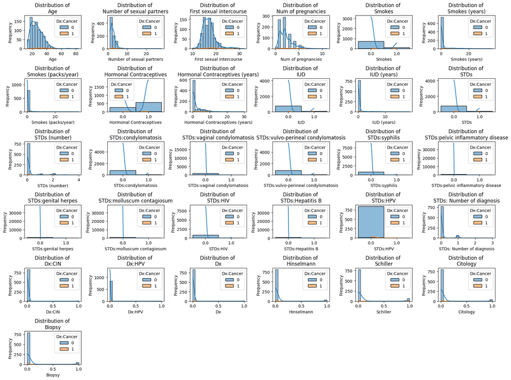

```python
#Visualizing the distribution of the remaining variables
#Creating a 6x5 grid of distribution plots
num_columns = 6
num_rows = (len(X.columns) + num_columns - 1) // num_columns # Calculate the optimal number of rows for appearance
fig, axes = plt.subplots(num_rows, num_columns, figsize=(17, 13))
axes = axes.flatten()

for col, column in enumerate(X.columns):
 sns.histplot(data=X, x=column, kde=True, bins=20, hue = y, color='red', ax=axes[col])
 axes[col].set_title(f'Distribution of \n{column}')
 axes[col].set_xlabel(column)
 axes[col].set_ylabel('Frequency')

#Remove empty subplots
for j in range(len(X.columns), len(axes)):
 fig.delaxes(axes[j])
plt.tight_layout()
```

Looking at the distributions of the categorical variables, it is very clear that they are right-skewed in favor of the majority class (`Dx:Cancer` = 0).

Whereas, for the numerical variables, `Age`, `Number of Sexual Partners`, `Num of Pregnancies`, `Smokes (years)`, `Hormonal Contraceptives (years)`, `STDs:Number`, `Smokes (packs/year)`, `IUD (years)`, and `STDs:Number of Diagnosis` all appear to be right skewed as well in favor of the majority class. The numerical variable that appears to be more normally distributed is the `First Sexual Intercourse` variable.

**This again implies the imbalanced nature of this data set and can lead to several problems mentioned below**

1. This imbalanced means that the model may place weight on variables by assuming that they are important towards the overall predictive performance.
2. The model will become very biased in predicting for the majority class.
3. This also means that the model will have a difficult time generalizing for the minority class which makes it difficult to classify them due to difficulty in uncovering the patterns.

**Approach to Handling Right-Skewedness**:

1. Can use log-transformed on right-skewed numerical variables in order for them to be more symmetric which reduces the impact of extreme values in the model.

```python
X_numeric = X.select_dtypes(include=['int64', 'float64'])

# Apply log transformation only to positive values
for column in X_numeric:
    if (X_numeric[column] > 0).all():  # Apply to only positive values
        X[column] = np.log1p(X_transformed[column])
```

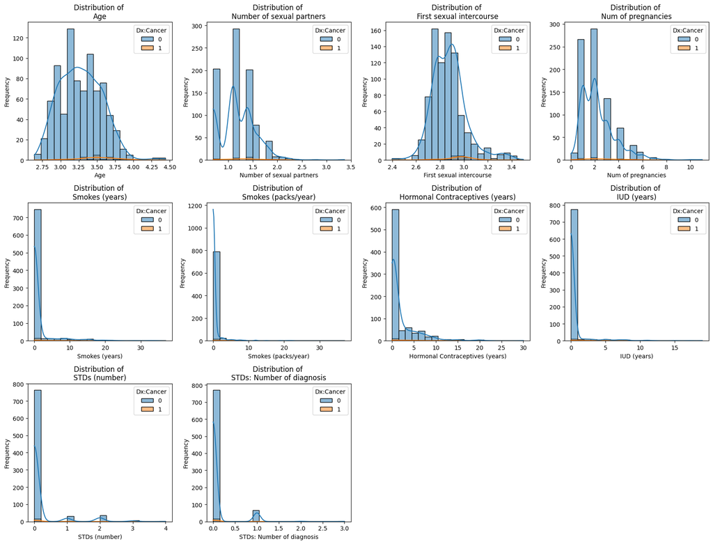

```python
#Visualizing the distribution of the numerical variables after log-transformed
#Creating a 4x3 grid of distribution plots
num_columns = 4
num_rows = (len(X_transformed.columns) + num_columns - 1) // num_columns # Calculate the optimal number of rows for appearance
fig, axes = plt.subplots(num_rows, num_columns, figsize=(17, 13))
axes = axes.flatten()

for col, column in enumerate(X_transformed.columns):
 sns.histplot(data=X_transformed, x=column, kde=True, bins=20, hue = y, color='red', ax=axes[col])
 axes[col].set_title(f'Distribution of \n{column}')
 axes[col].set_xlabel(column)
 axes[col].set_ylabel('Frequency')

#Remove empty subplots
for j in range(len(X_transformed.columns), len(axes)):
 fig.delaxes(axes[j])
plt.tight_layout()
```

After applying log-transformation on the numeric variables, some of their distribution appears to be more normal than before. Examples include variables such as `Age`, `Sexual Intercourse` and `Number of Sexual Partners`. However, it is clear that even with log-transformations, most of the numeric variables still appear to be very right-skewed which is unfortunately due to the nature of this dataset.

```python
#Splitting the data into training, validation, and testing sets
X_train, X_temp, y_train, y_temp = train_test_split(X_final, y, test_size = 0.7, random_state = 42, stratify = y)
X_test, X_val, y_test, y_val = train_test_split(X_temp, y_temp, test_size = 0.5, random_state = 42)
```

**`stratify = y`** is used to ensure that the class proportions in the training and testing dataset are the same as the original dataset. This means that the training and testing are representative of the overall class distribution. This is needed due to the imbalanced nature of this dataset.

```python
X_train.shape
```

```
(257, 31)
```

### Handling Data Imbalances

The aim of SMOTE is to generate synthetic data points for the minority class.

```python
from imblearn.over_sampling import SMOTE

smote = SMOTE(random_state = 42, k_neighbors = 3, sampling_strategy = 'auto')
X_train_res, y_train_res = smote.fit_resample(X_train, y_train)
```

```python
#Standardizing numerical variables
scaler = StandardScaler()

X_train_res[numerical_features] = scaler.fit_transform(X_train_res[numerical_features])
X_test[numerical_features] = scaler.transform(X_test[numerical_features])
X_val[numerical_features] = scaler.transform(X_val[numerical_features])
```

```python
# Only encode multi-class nominal features
encoding_features = [col for col in categorical_features
 if col not in binary_features]
print(f'encoding features: {encoding_features}')
```

```
encoding features: []
```

This shows that there are no categorical features that are multi-class. This suggests that one hot encoding or any form of encoding is unecessary.

### Introducing Class Weights for Heavily Imbalanced Dataset

The idea of class weights is to place emphasis on the minority class in the model which is heavily underepresented in this dataset. This allows the majority class to not dominate the learning process. Class weights are useful to avoid the model learning to predict only the majority class for every input because in real-life this is not useful. In the real-world, a model is more useful when its able to identify the 5% chance that someone has cancer compared to identifying 95% that they do not. A misclassification is really consequential for medical diagnosis as it affects life and death.

The logic behind class weights is to multiply the loss by a weight associated with that class. The higher the weight for that class, the more the model will focus on minimizing classification errors for that class. This helps the model pay more attention and improve its ability to correctly predict the minority class.

```python
import numpy as np
from sklearn.utils.class_weight import compute_class_weight

# Assuming y_train is your target variable
classes = np.array([0, 1])  # Convert the list into a numpy array
class_weights = compute_class_weight('balanced', classes=classes, y=y_train)

# Convert the result into a dictionary
class_weight_dict = {classes[i]: class_weights[i] for i in range(len(classes))}

print("Class Weights:", class_weight_dict)
```

```
Class Weights: {0: 0.5099206349206349, 1: 25.7}
```

### Model Architecture

```python
N, D = X_train_res.shape
print(N, D)
```

```
504 31
```

### Choice of Metric for FNN Performance

```python
from keras.metrics import AUC

#Designing the feedforward neural network model
model = tf.keras.models.Sequential([
    tf.keras.layers.Input(shape = (D,)),
    tf.keras.layers.Dense(16, activation = 'relu'),
    tf.keras.layers.Dense(1, activation = 'sigmoid')]
                                  )
model.compile(optimizer = Adam(learning_rate = 0.001), loss = 'binary_crossentropy', metrics = [AUC()])
```

Since my data is highly imbalanced, using the accuracy metric is not an accurate representation of how good the model is. This is because high accuracy reflects the model's biasedness towards the majority class. Therefore, the accuracy does not reflect how well the model is performing on the minority class. Hence, other metrics such as the confusion matrix and the AUC-ROC curve will be used as indicators of model performance. To prioritize this, the metric parameter will take in the AUC function from the `keras.metrics` package.

```python
model.summary()
```

```
Model: "sequential_274"
```

```
┏━━━━━━━━━━━━━━━━━━━━━━━━━━━━━━━━━┳━━━━━━━━━━━━━━━━━━━━━━━━┳━━━━━━━━━━━━━━━┓
┃ Layer (type)                    ┃ Output Shape           ┃       Param # ┃
┡━━━━━━━━━━━━━━━━━━━━━━━━━━━━━━━━━╇━━━━━━━━━━━━━━━━━━━━━━━━╇━━━━━━━━━━━━━━━┩
│ dense_786 (Dense)               │ (None, 16)             │           512 │
├─────────────────────────────────┼────────────────────────┼───────────────┤
│ dense_787 (Dense)               │ (None, 1)              │            17 │
└─────────────────────────────────┴────────────────────────┴───────────────┘
```

```
 Total params: 529 (2.07 KB)
```

```
 Trainable params: 529 (2.07 KB)
```

```
 Non-trainable params: 0 (0.00 B)
```

### Rationalization of parameter choices for neural network

**Input Dimension: 31**: This is the input dimension of the neural network which represents the number of features in the dataset excluding the target variable. 31 was the number of features remaining after some features were dropped due to proportion of missingness and some features were also dropped because they only had one class level which implies that they are likely redundant features that does not contribute to the model at all.

**Hidden Layer: 1**: The choice to use only one hidden layer is because it is usually sufficient to for any continuous function to be approximated given that there are enough hidden neurons in the hidden layer. With one hidden layer, it is less prone to overfitting because there are fewer parameters that are needed to be optimized which means it works really well with smaller datasets. Given that this dataset only has 858 instances and the training samples have 504 samples after SMOTE, one hidden layer should be sufficient and should be the most ideal.

**Number of Nodes in Hidden Layer: 16** 16 neurons was used purely as a starting point because neural networks generalize better when the neurons count is small. Higher neurons in the hidden layer leads to overfitting because the model will memorize the training data. Small starting point for neurons will be able to capture the essential patterns of the dataset much better.

**Activation Function (Hidden Layer): Rectified Linear Unit (ReLu)**: This activation function is known for introducing non-linearity to a neural network model which allows the model to learn complex patterns that are not always linear-based. Moreover, ReLU does not suffer from the vanishing gradient problem like other activation functions (namely Tanh or Sigmoid). This is because ReLU outputs a gradient of 1 for any positive input and 0 for any negative input. It has a faster convergence nature which leads to quicker training and is computationally inexpensive.

$$ \phi(x) = max(0, \alpha(x)) → \phi'(\alpha(x)) = \begin{cases} 1 & \text{if} \alpha(x) > 0 \\ 0 & \text{if} \alpha(x) \leq 0 \\ \end{cases} $$

**Activation Function (Output Layer): Sigmoid**: The classification for this neural network is to determined whether or not a person has cervical cancer which is a binary classification and therefore needs the sigmoid activation function. Useful for outputting probabilities as it maps any input as 0 or 1. The sigmoid function is denoted as follows:

$$ \sigma(x) = \frac{1}{1 + e^{-x}} $$

**Optimizer: Adam** The Adaptive Moment Estimation optimizer adjusts the learning rate for each parameter based on the parameter's gradient first and second moments. The learning rate is therefore adjusted depending on the weight of each parameter so its useful for features that have varying magnitudes.

**Loss: Binary Cross-entropy** Binary Cross-entropy is used for binary classification problems where the output layer uses the sigmoid activation function. It is useful to train classifiers to output probabilities and learn from mistakes when the model is confident but is wrong when classifying labels.

**Class Weight: {0: 0.509, 1: 25.7}** based on the computed class weight determined by the frequency of each class in the dataset.

```python
model_default = model.fit(X_train_res, y_train_res, validation_data = (X_val, y_val), class_weight = class_weight_dict, epochs = 50, verbose = False)
```

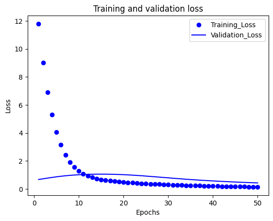

```python
history_def = model_default.history
history_def.keys()

loss_values = history_def['loss']
val_loss_values = history_def['val_loss']
epochs = range(1, len(loss_values) + 1)
plt.plot(epochs, loss_values, 'bo', label = 'Training_Loss')
plt.plot(epochs, val_loss_values, 'b', label = 'Validation_Loss')

#Adding x and y labels onto the graph
plt.title('Training and validation loss')
plt.xlabel('Epochs')
plt.ylabel('Loss')
plt.legend()
plt.show()
```

```python
train_loss, train_auc = model.evaluate(X_train_res, y_train_res)
print(f'Training Loss is {train_loss:.4f}')
print(f'Training AUC is {train_auc: .4f}')
```

```
16/16 ━━━━━━━━━━━━━━━━━━━━ 0s 3ms/step - auc_112: 0.7646 - loss: 0.3177
Training Loss is 0.2026
Training AUC is  1.0000
```

```python
test_loss, test_auc = model.evaluate(X_test, y_test)
print(f'Test loss is {test_loss:.4f}')
print(f'Test AUC is {test_auc:.4f}')
```

```
10/10 ━━━━━━━━━━━━━━━━━━━━ 0s 3ms/step - auc_112: 0.5061 - loss: 0.5993
Test loss is 0.5958
Test AUC is 0.5361
```

### FNN Performance Through Confusion Matrix

```
10/10 ━━━━━━━━━━━━━━━━━━━━ 0s 7ms/step
```

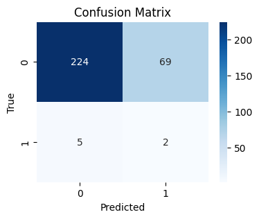

```python
from sklearn.metrics import confusion_matrix

# Generate model predictions
y_pred = model.predict(X_test).flatten()

# Convert probabilities to binary labels (0 or 1)
y_pred = np.where(y_pred > 0.5, 1, 0)

# Generate confusion matrix
cm = confusion_matrix(y_test, y_pred)

# Plot the confusion matrix
plt.figure(figsize=(4, 3))
sns.heatmap(cm, annot=True, fmt='d', cmap='Blues', xticklabels=['0', '1'], yticklabels=['0', '1'])
plt.xlabel('Predicted')
plt.ylabel('True')
plt.title('Confusion Matrix')
plt.show()
```

```python
print(classification_report(y_test, y_pred))
```

```
              precision    recall  f1-score   support

           0       0.98      0.76      0.86       293
           1       0.03      0.29      0.05         7

    accuracy                           0.75       300
   macro avg       0.50      0.53      0.45       300
weighted avg       0.96      0.75      0.84       300
```

```
10/10 ━━━━━━━━━━━━━━━━━━━━ 0s 2ms/step
```

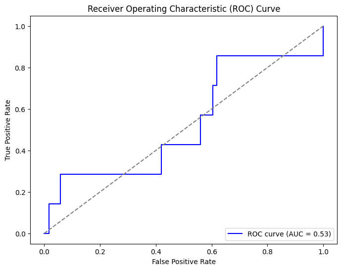

```python
# Once the best model is found, predict probabilities on the test set
y_pred_prob = model.predict(X_test)  # This gives the probability for class 1

# Compute ROC curve
fpr, tpr, thresholds = roc_curve(y_test, y_pred_prob)  # true labels vs predicted probabilities

# Compute AUC
roc_auc = auc(fpr, tpr)

# Plot ROC curve
plt.figure(figsize=(8, 6))
plt.plot(fpr, tpr, color='blue', label=f'ROC curve (AUC = {roc_auc:.2f})')
plt.plot([0, 1], [0, 1], color='gray', linestyle='--')  # Diagonal line
plt.xlabel('False Positive Rate')
plt.ylabel('True Positive Rate')
plt.title('Receiver Operating Characteristic (ROC) Curve')
plt.legend(loc='lower right')
plt.show()
```

Hence, the most useful metric to optimize will be the AUC-ROC Curve metric which means that our hyperparameter tuning should focus specifically on optimizing that value.

### Hyperparameter Tuning

Our hyperparameter tuning process will attempt to find the best combinations for the following parameters:

1. `Learning_rates`
2. `Dropout_rates`
3. `Num_nodes_options`
4. `Batch_size`
5. `Number of Epochs`

### Creating a generalized function to test the randomized search algorithm

```
Model 1 - History keys: dict_keys(['auc_123', 'loss', 'val_auc_123', 'val_loss'])
10/10 ━━━━━━━━━━━━━━━━━━━━ 0s 8ms/step
```

```
Model 2 - History keys: dict_keys(['auc_124', 'loss', 'val_auc_124', 'val_loss'])
10/10 ━━━━━━━━━━━━━━━━━━━━ 0s 7ms/step
```

```
Model 3 - History keys: dict_keys(['auc_125', 'loss', 'val_auc_125', 'val_loss'])
10/10 ━━━━━━━━━━━━━━━━━━━━ 0s 6ms/step
```

```
Model 4 - History keys: dict_keys(['auc_126', 'loss', 'val_auc_126', 'val_loss'])
10/10 ━━━━━━━━━━━━━━━━━━━━ 0s 5ms/step
```

```
Model 5 - History keys: dict_keys(['auc_127', 'loss', 'val_auc_127', 'val_loss'])
10/10 ━━━━━━━━━━━━━━━━━━━━ 0s 7ms/step
```

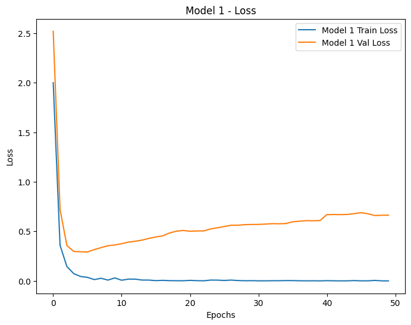

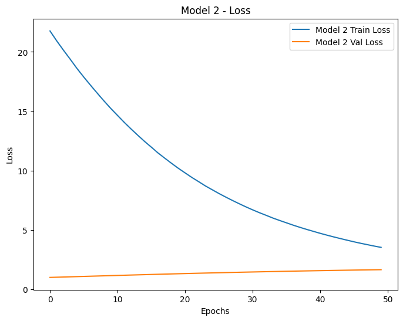

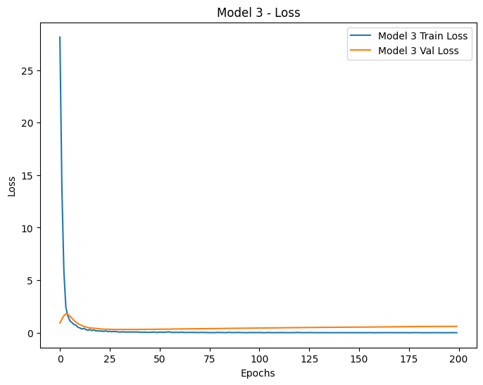

```
Best Parameters: {'learning_rate': 0.01, 'dropout_rate': 0.2, 'num_nodes': 32, 'batch_size': 16, 'epochs': 50}
Best AUC: 0.7713
```

```python
import random
import matplotlib.pyplot as plt
from sklearn.metrics import roc_auc_score
from keras.models import Sequential
from keras.layers import Dense, Dropout
from keras.optimizers import Adam
from keras.metrics import AUC

# Function to create a model with random hyperparameters
def create_model(learning_rate=0.001, dropout_rate=0.2, num_nodes=64):
    model = Sequential()
    model.add(Dense(num_nodes, input_dim=X_train_res.shape[1], activation='relu'))
    model.add(Dropout(dropout_rate))
    model.add(Dense(num_nodes, activation='relu'))
    model.add(Dropout(dropout_rate))
    model.add(Dense(1, activation='sigmoid'))
    model.compile(optimizer=Adam(learning_rate=learning_rate), loss='binary_crossentropy', metrics=[AUC()])
    return model

# Setting up the parameter grid
learning_rates = [0.0001, 0.001, 0.01, 0.1]
dropout_rates = [0.0, 0.2, 0.3, 0.4, 0.5]
num_nodes_options = [32, 64, 128, 256]
batch_sizes = [16, 32, 64, 128]
epochs_options = [50, 100, 200]

# Randomly sampling hyperparameters
num_samples = 5  # Number of samples to test
best_auc = 0
best_model = None
best_params = {}

# List to store the history of the top 3 models based on AUC
best_models_history = []
best_auc_values = []

for i in range(num_samples):
    # Randomly select hyperparameters
    learning_rate = random.choice(learning_rates)
    dropout_rate = random.choice(dropout_rates)
    num_nodes = random.choice(num_nodes_options)
    batch_size = random.choice(batch_sizes)
    epochs = random.choice(epochs_options)

    # Build the model with sampled hyperparameters
    model_new = create_model(learning_rate=learning_rate, dropout_rate=dropout_rate, num_nodes=num_nodes)

    # Train the model with class weights
    history = model_new.fit(X_train_res, y_train_res, batch_size=batch_size, epochs=epochs, verbose=0,
                            class_weight=class_weight, validation_data=(X_test, y_test))

    # Print available keys in the history dictionary to debug the issue
    print(f"Model {i+1} - History keys: {history.history.keys()}")

    #Calculating AUC manually
    y_pred_proba = model_new.predict(X_test)  # Probability predictions (not hard labels)
    auc_score = roc_auc_score(y_test, y_pred_proba)  # Compute AUC using sklearn's roc_auc_score

    #Track the best model and history based on AUC
    if auc_score > best_auc:
        best_auc = auc_score
        best_model = model_new
        best_params = {
            'learning_rate': learning_rate,
            'dropout_rate': dropout_rate,
            'num_nodes': num_nodes,
            'batch_size': batch_size,
            'epochs': epochs
        }
        best_models_history = [history]  # Reset with the current best model history
        best_auc_values = [auc_score]

    elif len(best_models_history) < 3:
        best_models_history.append(history)  # Store additional top-performing models' history

        best_auc_values.append(auc_score)
    elif auc_score > min(best_auc_values):
        #Replace the model with the smallest AUC
        worst_index = best_auc_values.index(min(best_auc_values))
        best_models_history[worst_index] = history
        best_auc_values[worst_index] = auc_score

# Plotting the learning curves for the best three models individually
for i, history in enumerate(best_models_history):

    # Plotting the training & validation loss for each model
    plt.figure(figsize=(8, 6))
    plt.plot(history.history['loss'], label=f'Model {i+1} Train Loss')
    plt.plot(history.history['val_loss'], label=f'Model {i+1} Val Loss')
    plt.title(f'Model {i+1} - Loss')
    plt.xlabel('Epochs')
    plt.ylabel('Loss')
    plt.legend()
    plt.show()

print(f"Best Parameters: {best_params}")
print(f"Best AUC: {best_auc:.4f}")
```

## Part 3: Evaluation and Interpretation

### Test Set Evaluation

```python
test_loss, test_AUC = best_model.evaluate(X_test, y_test)
print(f'Test loss is {test_loss:.4f}')
print(f'Test AUC is {test_AUC:.4f}')
```

```
10/10 ━━━━━━━━━━━━━━━━━━━━ 0s 2ms/step - auc_124: 0.4959 - loss: 0.6544
Test loss is 0.6630
Test AUC is 0.5695
```

```
10/10 ━━━━━━━━━━━━━━━━━━━━ 0s 2ms/step
Confusion Matrix:
[[292   1]
 [  7   0]]
```

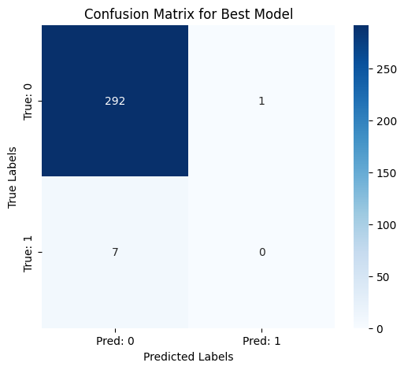

```python
#After hyperparameter tuning found the best model, it is used to predict on the test set and print out the confusion matrix
y_pred = (best_model.predict(X_test) > 0.5).astype(int)  # Convert probabilities to binary class predictions

#Computing the confusion matrix
cm = confusion_matrix(y_test, y_pred)

#Printing the confusion matrix
print("Confusion Matrix:")
print(cm)

#Visualizing the confusion matrix using a heatmap
plt.figure(figsize=(6, 5))
sns.heatmap(cm, annot=True, fmt='d', cmap='Blues', xticklabels=['Pred: 0', 'Pred: 1'], yticklabels=['True: 0', 'True: 1'])
plt.xlabel('Predicted Labels')
plt.ylabel('True Labels')
plt.title('Confusion Matrix for Best Model')
plt.show()
```

```
10/10 ━━━━━━━━━━━━━━━━━━━━ 0s 2ms/step
```

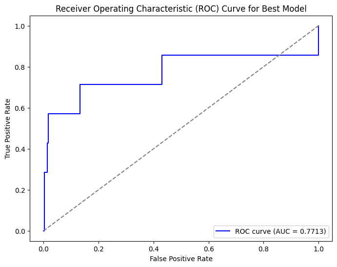

```python
# Once the best model is found, predict probabilities on the test set
y_pred_prob = best_model.predict(X_test)  # This gives the probability for class 1

# Compute ROC curve
fpr, tpr, thresholds = roc_curve(y_test, y_pred_prob)  # true labels vs predicted probabilities

# Compute AUC
roc_auc = auc(fpr, tpr)

# Plot ROC curve
plt.figure(figsize=(8, 6))
plt.plot(fpr, tpr, color='blue', label=f'ROC curve (AUC = {roc_auc:.4f})')
plt.plot([0, 1], [0, 1], color='gray', linestyle='--')  # Diagonal line
plt.xlabel('False Positive Rate')
plt.ylabel('True Positive Rate')
plt.title('Receiver Operating Characteristic (ROC) Curve for Best Model')
plt.legend(loc='lower right')
plt.show()
```

### Model Interpretation

The model is limited by the fact that even with using SMOTE to oversample the minority class and using class weights to add penalty for wrongful classifications, there needs to be more training data with more observations with the minority class in order for the model to learn more complicated patterns that can correctly classify cancer outcomes. Having more observation with actual data from the hospital will make training model much more better.

The variables that likely influenced the results of the model is the right-skewed variables in this dataset. Especially, the right-skewed categorical variables and the right-skewed numerical variables. Despite, the right skewed-numerical variables being transformed using log transformation, the shape of their distribution did not change much. Therefore, these variables were more biased towards the majority class.

### Conclusion

The choice to use the AUC Metric is because accuracy is not a good metric for an imbalanced data since the model will keep on classifying the majority class. Hence, looking at AUC and the confusion matrix would show how well the model is at classifying.

There were improvement following the hyperparameter tuning process. Namely, the AUC metric increased and the confusion matrix also improved with less wrongful classifications than the initial model. Here, are the differences between the two:

**Initial Model Test AUC**: 0.5361 **Best Model Test AUC**: 0.5695

**Initial Model Confusion Matrix**:

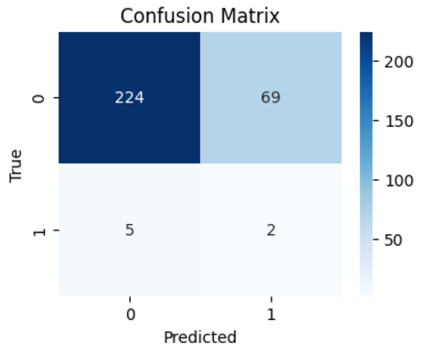

**Final Model Confusion Matrix**:

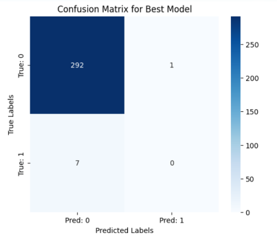

The final model classifies the non-cancer cases much more effectively than the initial model. However, the initial model was able to classifying some cancerous cases correctly but had several wrongful classifications.

For instance, the initial model classified those with not cancer in the cancer category which showcases high Type I Error. It had less wrongful classification for those that have cancer but predicted them as no (5 total) which means the initial model had less cases of Type II Error. The final model had only 7 misclassifications for those with cancer but predicted as no. The issue with this is that Type II error in medical diagnosis is costly as it can affect a person's life. By having wrongful misclassifications, it showcases the limitations of this dataset and the model.

Overall, while the AUC improved for the final model, we can see that the confusion matrix showcases the limitation of this particular dataset as there were simply not enough instances of good data for the minority class. This skewed the prediction drastically towards the majority class which means the model is really good at handling majority class classification. However, even with hyperparameter tuning, the model would still only classify the majority class well and struggle with the minority class. If possible, when the hospital is able to collect more data, the model may be better at classifying.